# The Financial Meltdown and house prices in Ames, Iowa.

## 0.1 Preliminaries

```r
library(skimr)
library(broom)
library(Hmisc)
library(rms)
library(pROC)
library(ROCR)
library(tidyverse)
```

# 1 Task 1: Data Source

The orginal Data is openly accessible through https://www.kaggle.com/c/house-prices-advanced-regression-techniques/data

Data set contains information from the Ames Assessor’s Office for individual residential properties sold in Ames, IA from 2006 to 2010.

SOURCES: Ames, Iowa Assessor’s Office

# 2 Task 2: Load and Tidy the Data

```r
library(readr)
Housing_price <- read_csv("Housing_price.csv",
    col_types = cols(BldgType = col_factor(levels = c("1Fam",
        "2fmCon", "Duplex", "TwnhsE", "Twnhs")),
        GarageType = col_factor(levels = c("Attchd",
            "Detchd", "BuiltIn", "CarPort",
            "street", "Basment", "2Types")),
        Id = col_skip()))


Housing_price$months_to_crisis = 24105 - Housing_price$MoSold - (Housing_price$YrSold * 12)

Housing_price$before_crisis <-factor(c(  "No","yes"))[
                     findInterval(Housing_price$months_to_crisis , c(-Inf,0, Inf) ) ]

Housing_price$updated<-factor(c( "historical", "80s", "90s", "recent"))[
                     findInterval(Housing_price$YearRemodAdd , c(0, 1980, 1990, 2000, Inf) ) ]

Housing_price = Housing_price %>%
  filter(months_to_crisis >= -18 & months_to_crisis  <= 18)
```

I considered the event that set the crisis on move was the collapse of the investment bank Lehman Brothers September 2008, so houses were sold before that 09/2008 considered sold before the crisis. I created a new column “before_crisis” and I add a value of yes for houses sold before the crisis and No for houses sold after. I used MoSold and YrSold columns to obtain this information

I converted YearRemodAdd column into 4 categories and added it to a new column and I named it “updated”. if house remodeling happened before 1980 I classified it to historical. 1980-1990: 80s 1990-2000 90s and after 2000: recent

Only houses sold 18 months before and after September 2008 were selected.

# 3 Task 3: Listing of My Tibble

```r
glimpse(Housing_price)
```

```
Observations: 996
Variables: 17
$ LotArea          <int> 8450, 9600, 11250, 14260, 14115, 10084, 10382...
$ BldgType         <fctr> 1Fam, 1Fam, 1Fam, 1Fam, 1Fam, 1Fam, 1Fam, 1F...
$ OverallQual      <int> 7, 6, 7, 8, 5, 8, 7, 7, 5, 5, 5, 7, 6, 7, 6, ...
$ OverallCond      <int> 5, 8, 5, 5, 5, 5, 6, 5, 6, 5, 6, 5, 5, 8, 7, ...
$ YearRemodAdd     <int> 2003, 1976, 2002, 2000, 1995, 2005, 1973, 195...
$ TotalBsmtSF      <int> 856, 1262, 920, 1145, 796, 1686, 1107, 952, 9...
$ GrLivArea        <int> 1710, 1262, 1786, 2198, 1362, 1694, 2090, 177...
$ FullBath         <int> 2, 2, 2, 2, 1, 2, 2, 2, 1, 1, 1, 2, 1, 1, 1, ...
$ HalfBath         <int> 1, 0, 1, 1, 1, 0, 1, 0, 0, 0, 0, 0, 1, 0, 0, ...
$ BedroomAbvGr     <int> 3, 3, 3, 4, 1, 3, 3, 2, 2, 3, 2, 3, 2, 2, 2, ...
$ GarageType       <fctr> Attchd, Attchd, Attchd, Attchd, Attchd, Attc...
$ MoSold           <int> 2, 5, 9, 12, 10, 8, 11, 4, 1, 2, 9, 8, 5, 7, ...
$ YrSold           <int> 2008, 2007, 2008, 2008, 2009, 2007, 2009, 200...
$ SalePrice        <int> 208500, 181500, 223500, 250000, 143000, 30700...
$ months_to_crisis <dbl> 7, 16, 0, -3, -13, 13, -14, 5, 8, 7, 0, 13, 4...
$ before_crisis    <fctr> yes, yes, yes, No, No, yes, No, yes, yes, ye...
$ updated          <fctr> recent, historical, recent, recent, 90s, rec...
```

subjects: 996

# 4 Task 4: Code Book

| Variable | Type | Details |
| --- | --- | --- |
| `LotArea` | quantitative | Lot size in square feet |
| `BldgType` | multi-categorical | Type of dwelling: 1Fam,2fmCon,Duplex,TwnhsE,Twnhs |
| `OverallQual` | multi-categorical | Overall material and finish quality(1-10) |
| `OverallCond` | multi-categorical | Overall condition rating (1-10) |
| `TotalBsmtSF` | quantitative | Total square feet of basement area |
| `GrLivArea` | quantitative | Above grade (ground) living area square feet |
| `FullBath` | quantitative | Full bathrooms above grade |
| `HalfBath` | quantitative | Half baths above grade |
| `BedroomAbvGr` | quantitative | Number of bedrooms above basement level |
| `GarageType` | multi-categorical | Garage location: Attchd,Detchd,BuiltIn,CarPort,street,Basment,2Types |
| `SalePrice` | quantitative | the property’s sale price in dollars. |
| `months_to_crisis` | quantitative | duration from the crisis in monthes. |
| `before_crisis` | binary | if the house solde before sep 2008 |
| `updated` | multi-categorical | Remodel era: historical,80s,90s,recent |

# 5 Task 5: My Subjects

# 6 Task 6: My Variables

**Lot Area:** Lot size in square feet

**BldgType:** Type of dwelling

```
   1Fam    Single-family Detached
   2FmCon    Two-family Conversion; originally built as one-family dwelling
   Duplx    Duplex
   TwnhsE    Townhouse End Unit
   TwnhsI    Townhouse Inside Unit
```

**OverallQual :** Rates the overall material and finish of the house

```
   10    Very Excellent
   9    Excellent
   8    Very Good
   7    Good
   6    Above Average
   5    Average
   4    Below Average
   3    Fair
   2    Poor
   1    Very Poor
```

**OverallCond :** Rates the overall condition of the house

```
   10    Very Excellent
   9    Excellent
   8    Very Good
   7    Good
   6    Above Average
   5    Average
   4    Below Average
   3    Fair
   2    Poor
   1    Very Poor
```

**TotalBsmSF :** Total square feet of basement area

**GrLivArea :** Above grade (ground) living area square feet

**FullBath :** Full bathrooms above grade(does NOT include basement bathrooms)

**HalfBath:** Half baths above grade (does NOT include basement half baths)

**BedroomAbvGr:** Bedrooms above grade (does NOT include basement bedrooms)

**Garage Type:** Garage location

```
   2Types    More than one type of garage
   Attchd    Attached to home
   Basment    Basement Garage
   BuiltIn    Built-In (Garage part of house - typically has room above garage)
   CarPort    Car Port
   Detchd    Detached from home
   Street    No Garage
```

**SalePrice:** the property’s sale price in dollars.

**before_crisis:** yes if the house was sold before sep 2008, no if after that date.

**updated:** Remodel date (same as construction date if no remodeling or additions)

```
  historical: last remodel happened before 1980
  80s: last remodel happened  between 1980    -1990
  90s: last remodel happened between 1990    -2000
  recent: last remodel happened after 2000
```

# 7 Task 7: My Planned Linear Regression Model

the outcome is SalePrice, I’m going to use quantitative variable:`LotArea`, `OverallQual` , `OverallCond` , `GrLivArea` , `FullBath` , `BedroomAbvGr` multi-categorical variable: `updated`

and check the affect of including months_to_crisis on the model

```r
T7_data = Housing_price %>%
  select(LotArea,  OverallQual  , OverallCond   , GrLivArea , FullBath  , BedroomAbvGr,updated,months_to_crisis,SalePrice)
skim(T7_data)
```

```
Skim summary statistics
 n obs: 996
 n variables: 9

Variable type: factor
 variable missing complete   n n_unique
  updated       0      996 996        4
                            top_counts ordered
 rec: 393, his: 376, 90s: 173, 80s: 54   FALSE

Variable type: integer
     variable missing complete   n      mean       sd    p0       p25
 BedroomAbvGr       0      996 996      2.86     0.81     0      2
     FullBath       0      996 996      1.57     0.54     0      1
    GrLivArea       0      996 996   1515.65   529.37   438   1131.75
      LotArea       0      996 996  10547.06 11216.4   1300   7598.25
  OverallCond       0      996 996      5.63     1.13     1      5
  OverallQual       0      996 996      6.11     1.38     1      5
    SalePrice       0      996 996 181240.7  78042.19 34900 129975
   median      p75   p100     hist
      3        3        8 ▁▃▇▂▁▁▁▁
      2        2        3 ▁▁▆▁▁▇▁▁
   1465     1768     5642 ▃▇▃▁▁▁▁▁
   9468.5  11461.5 215245 ▇▁▁▁▁▁▁▁
      5        6        9 ▁▁▁▇▂▂▁▁
      6        7       10 ▁▁▂▇▇▆▃▁
 164800   213062.5 745000 ▃▇▂▁▁▁▁▁

Variable type: numeric
         variable missing complete   n mean    sd  p0 p25 median p75 p100
 months_to_crisis       0      996 996 0.99 10.69 -18  -9      2  12   18
     hist
 ▃▇▃▃▇▃▃▇
```

```r
mod1 = lm(SalePrice~LotArea+  OverallQual   + OverallCond   + GrLivArea + FullBath   +BedroomAbvGr+updated,data=T7_data)
glance(mod1)
```

```
  r.squared adj.r.squared    sigma statistic       p.value df    logLik
1 0.7272735     0.7247841 40941.73  292.1493 4.976058e-271 10 -11985.66
       AIC      BIC     deviance df.residual
1 23993.33 24047.27 1.652758e+12         986
```

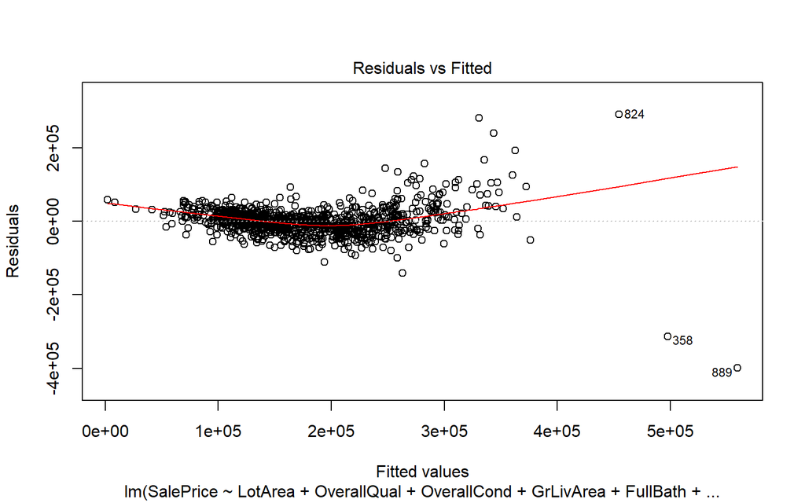

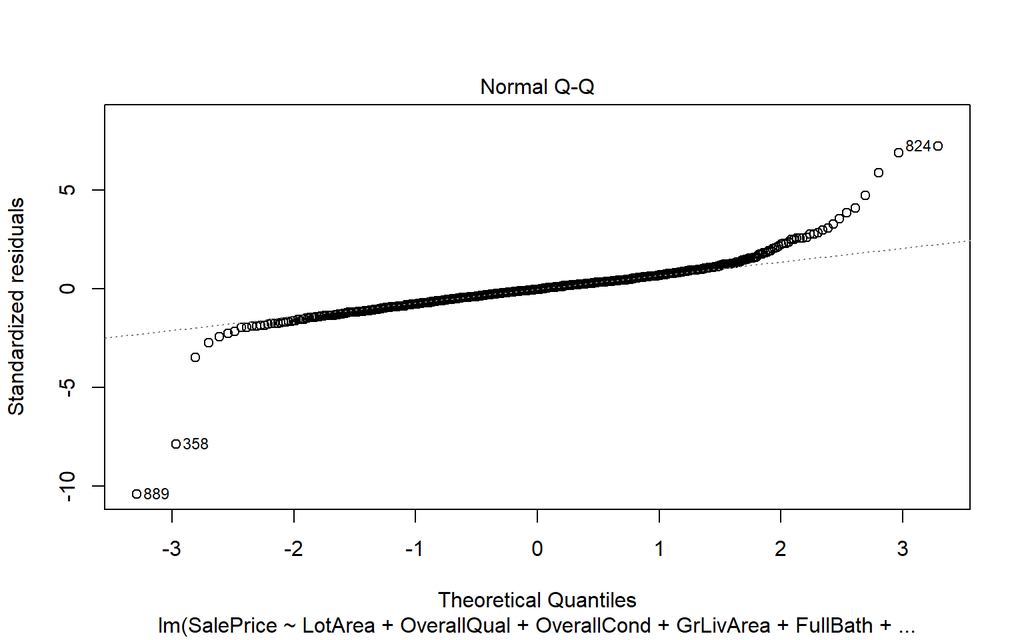

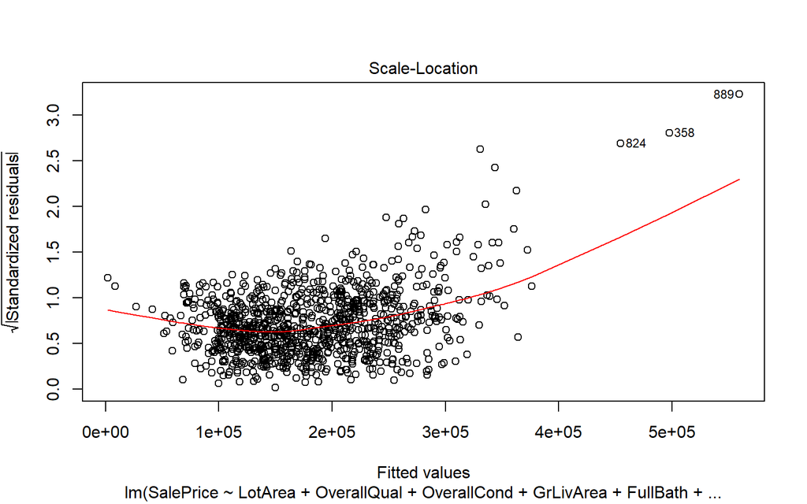

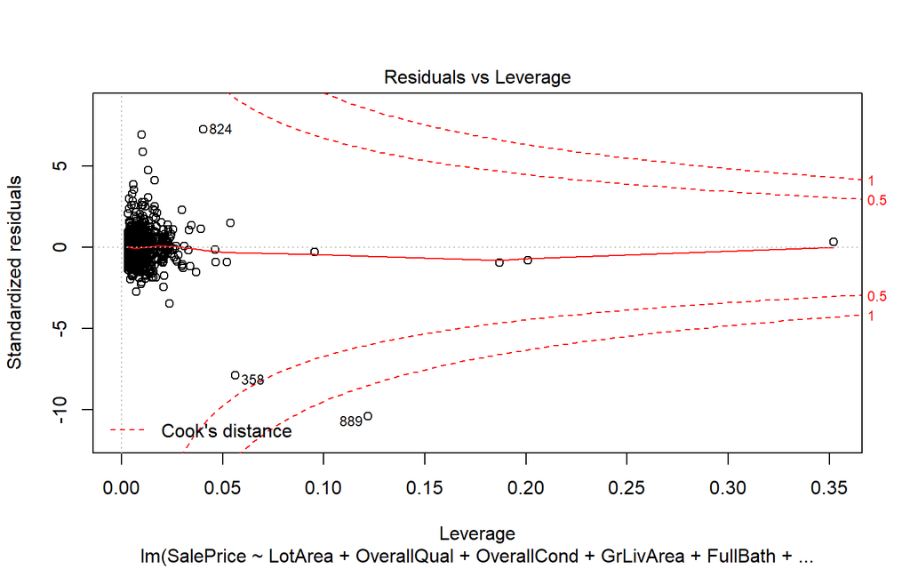

```r
plot(mod1)
```

```r
anova(mod1)
```

```
Analysis of Variance Table

Response: SalePrice
              Df     Sum Sq    Mean Sq   F value    Pr(>F)
LotArea        1 2.9244e+11 2.9244e+11  174.4625 < 2.2e-16 ***
OverallQual    1 3.6360e+12 3.6360e+12 2169.1509 < 2.2e-16 ***
OverallCond    1 1.4276e+09 1.4276e+09    0.8516    0.3563
GrLivArea      1 3.6753e+11 3.6753e+11  219.2624 < 2.2e-16 ***
FullBath       1 9.6344e+09 9.6344e+09    5.7477    0.0167 *
BedroomAbvGr   1 5.3063e+10 5.3063e+10   31.6564 2.397e-08 ***
updated        3 4.7291e+10 1.5764e+10    9.4042 3.942e-06 ***
Residuals    986 1.6528e+12 1.6762e+09
---
Signif. codes:  0 '***' 0.001 '**' 0.01 '*' 0.05 '.' 0.1 ' ' 1
```

```r
mod2 = lm(SalePrice~months_to_crisis+LotArea+  OverallQual  + OverallCond   + GrLivArea + FullBath   +BedroomAbvGr+updated,data=T7_data)
glance(mod2)
```

```
  r.squared adj.r.squared   sigma statistic       p.value df   logLik
1 0.7273056     0.7245371 40960.1  262.7102 8.259144e-270 11 -11985.6
       AIC      BIC     deviance df.residual
1 23995.21 24054.05 1.652564e+12         985
```

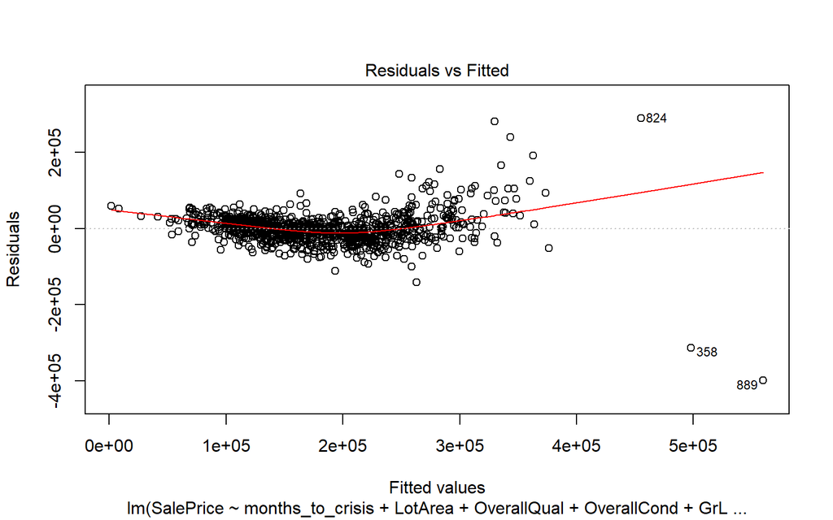

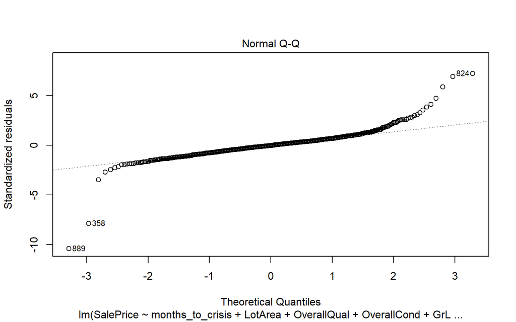

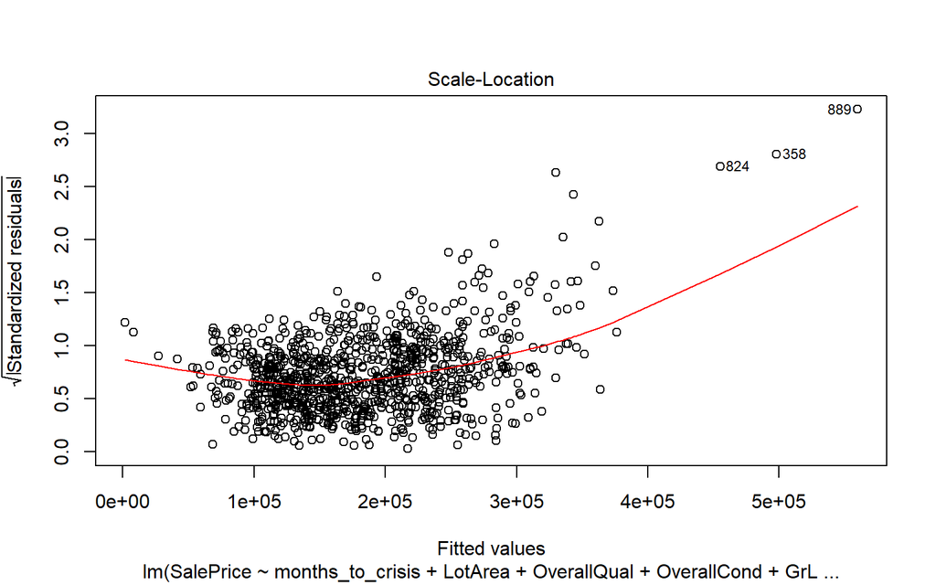

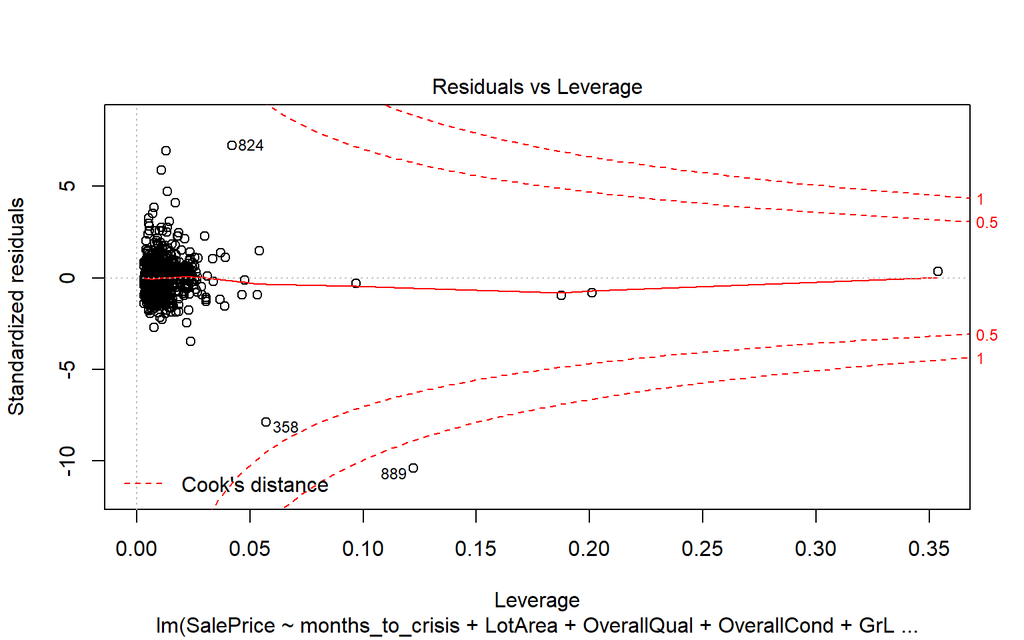

```r
plot(mod2)
```

```r
anova(mod2)
```

```
Analysis of Variance Table

Response: SalePrice
                  Df     Sum Sq    Mean Sq   F value    Pr(>F)
months_to_crisis   1 1.3463e+09 1.3463e+09    0.8025   0.37058
LotArea            1 2.9153e+11 2.9153e+11  173.7665 < 2.2e-16 ***
OverallQual        1 3.6362e+12 3.6362e+12 2167.3043 < 2.2e-16 ***
OverallCond        1 1.4393e+09 1.4393e+09    0.8579   0.35455
GrLivArea          1 3.6698e+11 3.6698e+11  218.7351 < 2.2e-16 ***
FullBath           1 9.6766e+09 9.6766e+09    5.7677   0.01651 *
BedroomAbvGr       1 5.3532e+10 5.3532e+10   31.9076 2.115e-08 ***
updated            3 4.6910e+10 1.5637e+10    9.3201 4.439e-06 ***
Residuals        985 1.6526e+12 1.6777e+09
---
Signif. codes:  0 '***' 0.001 '**' 0.01 '*' 0.05 '.' 0.1 ' ' 1
```

```r
step(mod2)
```

```
Start:  AIC=21166.68
SalePrice ~ months_to_crisis + LotArea + OverallQual + OverallCond +
    GrLivArea + FullBath + BedroomAbvGr + updated

                   Df  Sum of Sq        RSS   AIC
- months_to_crisis  1 1.9429e+08 1.6528e+12 21165
- OverallCond       1 3.2950e+08 1.6529e+12 21165
<none>                           1.6526e+12 21167
- FullBath          1 4.8358e+09 1.6574e+12 21168
- BedroomAbvGr      1 3.2772e+10 1.6853e+12 21184
- updated           3 4.6910e+10 1.6995e+12 21189
- LotArea           1 5.2889e+10 1.7055e+12 21196
- GrLivArea         1 3.0410e+11 1.9567e+12 21333
- OverallQual       1 7.3383e+11 2.3864e+12 21531

Step:  AIC=21164.8
SalePrice ~ LotArea + OverallQual + OverallCond + GrLivArea +
    FullBath + BedroomAbvGr + updated

               Df  Sum of Sq        RSS   AIC
- OverallCond   1 3.3459e+08 1.6531e+12 21163
<none>                       1.6528e+12 21165
- FullBath      1 4.7626e+09 1.6575e+12 21166
- BedroomAbvGr  1 3.2581e+10 1.6853e+12 21182
- updated       3 4.7291e+10 1.7000e+12 21187
- LotArea       1 5.3075e+10 1.7058e+12 21194
- GrLivArea     1 3.0420e+11 1.9570e+12 21331
- OverallQual   1 7.3373e+11 2.3865e+12 21529

Step:  AIC=21163
SalePrice ~ LotArea + OverallQual + GrLivArea + FullBath + BedroomAbvGr +
    updated

               Df  Sum of Sq        RSS   AIC
<none>                       1.6531e+12 21163
- FullBath      1 5.7856e+09 1.6589e+12 21165
- BedroomAbvGr  1 3.4233e+10 1.6873e+12 21181
- updated       3 4.7729e+10 1.7008e+12 21185
- LotArea       1 5.2832e+10 1.7059e+12 21192
- GrLivArea     1 3.0459e+11 1.9577e+12 21329
- OverallQual   1 7.3660e+11 2.3897e+12 21528
```

```
Call:
lm(formula = SalePrice ~ LotArea + OverallQual + GrLivArea +
    FullBath + BedroomAbvGr + updated, data = T7_data)

Coefficients:
      (Intercept)            LotArea        OverallQual
       -7.237e+04          6.719e-01          2.870e+04
        GrLivArea           FullBath       BedroomAbvGr
        5.333e+01          6.215e+03         -9.048e+03
       updated90s  updatedhistorical      updatedrecent
        8.453e+03         -3.133e+03          1.551e+04
```

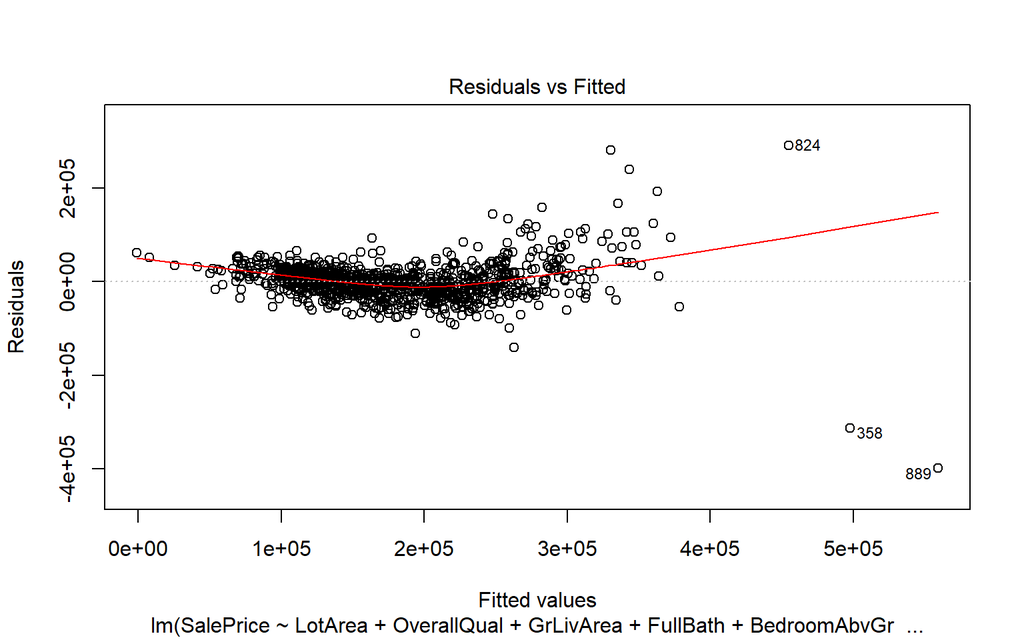

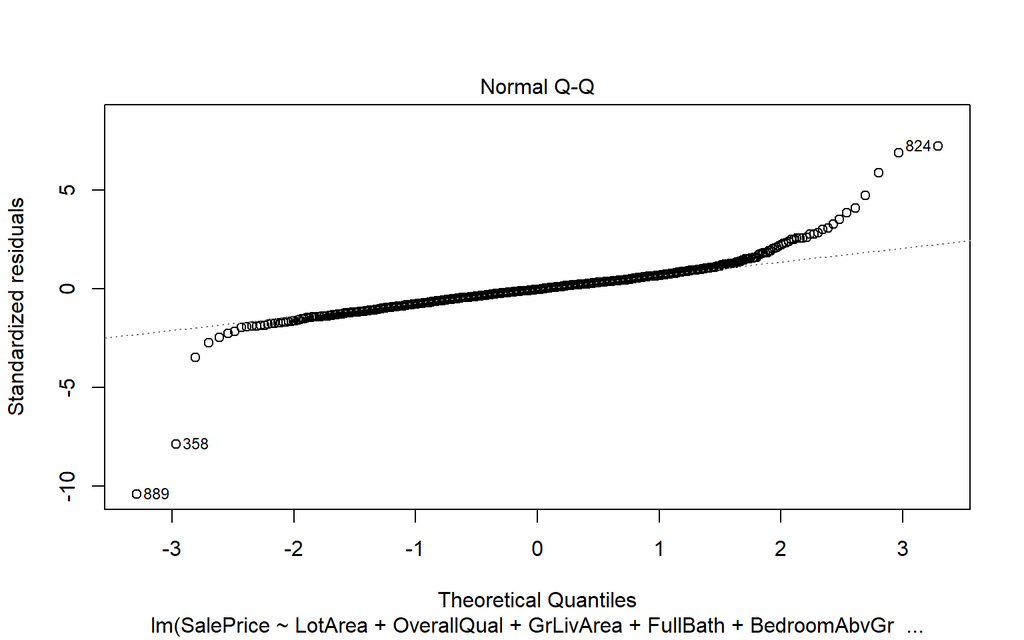

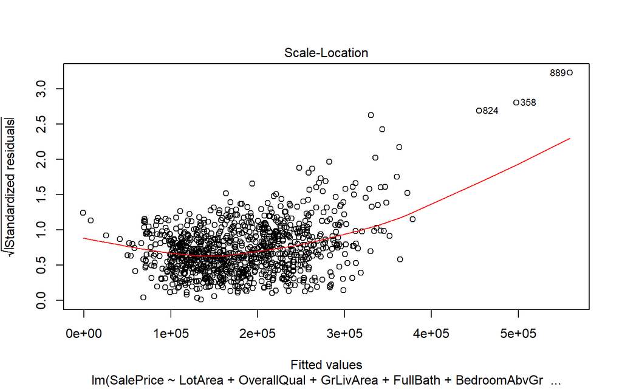

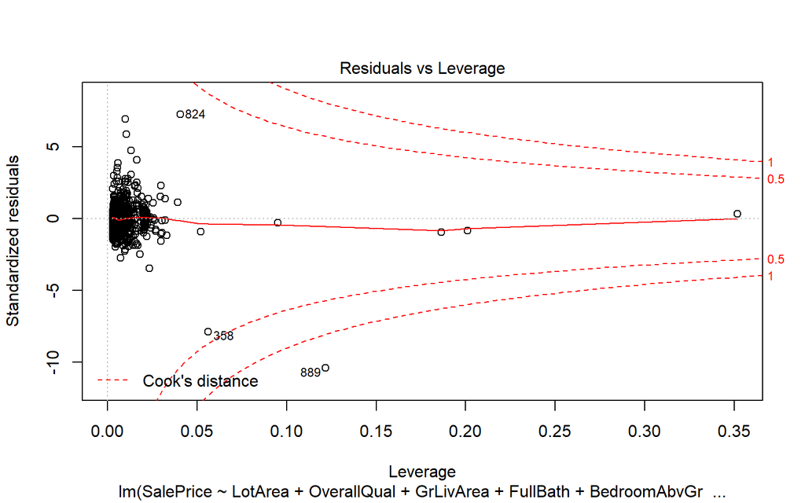

```r
mod3 = lm(formula = SalePrice ~ LotArea + OverallQual + GrLivArea +
    FullBath + BedroomAbvGr + updated, data = T7_data)
plot(mod3)
```

```r
anova(mod3)
```

```
Analysis of Variance Table

Response: SalePrice
              Df     Sum Sq    Mean Sq   F value    Pr(>F)
LotArea        1 2.9244e+11 2.9244e+11  174.6041 < 2.2e-16 ***
OverallQual    1 3.6360e+12 3.6360e+12 2170.9113 < 2.2e-16 ***
GrLivArea      1 3.6878e+11 3.6878e+11  220.1828 < 2.2e-16 ***
FullBath       1 9.7912e+09 9.7912e+09    5.8459   0.01579 *
BedroomAbvGr   1 5.2317e+10 5.2317e+10   31.2366 2.955e-08 ***
updated        3 4.7729e+10 1.5910e+10    9.4992 3.447e-06 ***
Residuals    987 1.6531e+12 1.6749e+09
---
Signif. codes:  0 '***' 0.001 '**' 0.01 '*' 0.05 '.' 0.1 ' ' 1
```

Im still working on non linearity of the residuals, Im going to transfere the outcome and re fit lm

# 8 Task 8: My Planned Logistic Regression Model

```r
T8_data = Housing_price %>%
  select(LotArea,  OverallQual  , OverallCond   , GrLivArea , FullBath  , BedroomAbvGr,updated,before_crisis,SalePrice)
skim(T8_data)
```

```
Skim summary statistics
 n obs: 996
 n variables: 9

Variable type: factor
      variable missing complete   n n_unique
 before_crisis       0      996 996        2
       updated       0      996 996        4
                            top_counts ordered
              yes: 559, No: 437, NA: 0   FALSE
 rec: 393, his: 376, 90s: 173, 80s: 54   FALSE

Variable type: integer
     variable missing complete   n      mean       sd    p0       p25
 BedroomAbvGr       0      996 996      2.86     0.81     0      2
     FullBath       0      996 996      1.57     0.54     0      1
    GrLivArea       0      996 996   1515.65   529.37   438   1131.75
      LotArea       0      996 996  10547.06 11216.4   1300   7598.25
  OverallCond       0      996 996      5.63     1.13     1      5
  OverallQual       0      996 996      6.11     1.38     1      5
    SalePrice       0      996 996 181240.7  78042.19 34900 129975
   median      p75   p100     hist
      3        3        8 ▁▃▇▂▁▁▁▁
      2        2        3 ▁▁▆▁▁▇▁▁
   1465     1768     5642 ▃▇▃▁▁▁▁▁
   9468.5  11461.5 215245 ▇▁▁▁▁▁▁▁
      5        6        9 ▁▁▁▇▂▂▁▁
      6        7       10 ▁▁▂▇▇▆▃▁
 164800   213062.5 745000 ▃▇▂▁▁▁▁▁
```

```r
lr1<- glm(before_crisis~LotArea+  OverallQual   + OverallCond   + GrLivArea + FullBath   +BedroomAbvGr+updated,data=T8_data,
family="binomial"(link="logit"))
summary(lr1)
```

```
Call:
glm(formula = before_crisis ~ LotArea + OverallQual + OverallCond +
    GrLivArea + FullBath + BedroomAbvGr + updated, family = binomial(link = "logit"),
    data = T8_data)

Deviance Residuals:
    Min       1Q   Median       3Q      Max
-1.6523  -1.2728   0.9748   1.0631   1.3844

Coefficients:
                    Estimate Std. Error z value Pr(>|z|)
(Intercept)       -1.067e+00  6.181e-01  -1.726   0.0844 .
LotArea            4.388e-06  6.480e-06   0.677   0.4983
OverallQual        7.665e-03  6.782e-02   0.113   0.9100
OverallCond        5.472e-02  6.097e-02   0.897   0.3695
GrLivArea          3.404e-05  1.974e-04   0.172   0.8631
FullBath          -1.766e-01  1.719e-01  -1.027   0.3042
BedroomAbvGr       1.967e-01  1.012e-01   1.944   0.0518 .
updated90s         5.811e-01  3.201e-01   1.815   0.0695 .
updatedhistorical  5.589e-01  2.991e-01   1.868   0.0617 .
updatedrecent      6.703e-01  3.019e-01   2.221   0.0264 *
---
Signif. codes:  0 '***' 0.001 '**' 0.01 '*' 0.05 '.' 0.1 ' ' 1

(Dispersion parameter for binomial family taken to be 1)

    Null deviance: 1365.8  on 995  degrees of freedom
Residual deviance: 1353.7  on 986  degrees of freedom
AIC: 1373.7

Number of Fisher Scoring iterations: 4
```

```r
anova(lr1)
```

```
Analysis of Deviance Table

Model: binomial, link: logit

Response: before_crisis

Terms added sequentially (first to last)

             Df Deviance Resid. Df Resid. Dev
NULL                           995     1365.8
LotArea       1   0.8971       994     1364.9
OverallQual   1   0.0015       993     1364.9
OverallCond   1   1.6464       992     1363.2
GrLivArea     1   0.8724       991     1362.3
FullBath      1   0.3183       990     1362.0
BedroomAbvGr  1   3.3658       989     1358.7
updated       3   5.0102       986     1353.7
```

```r
glance(lr1)
```

```
  null.deviance df.null   logLik      AIC      BIC deviance df.residual
1      1365.768     995 -676.828 1373.656 1422.693 1353.656         986
```

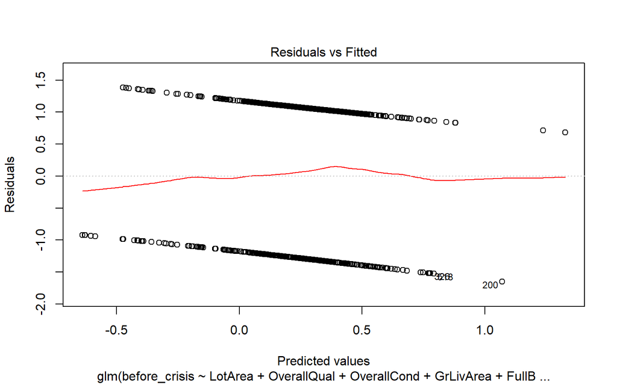

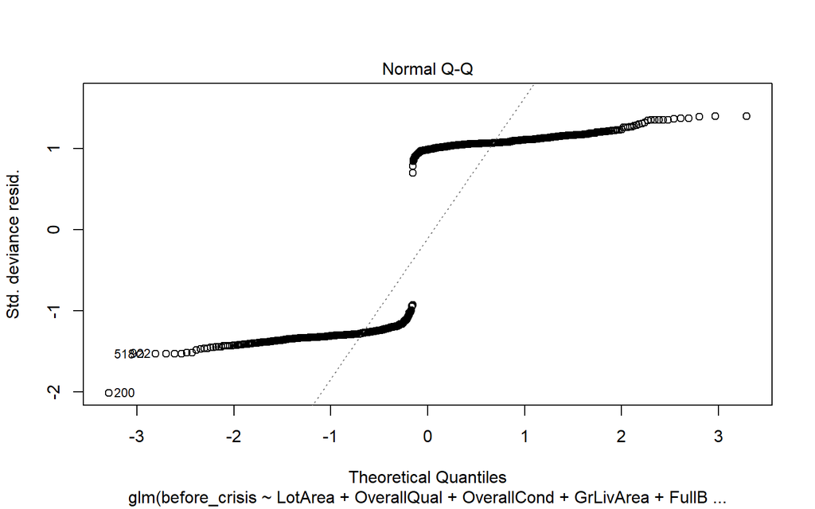

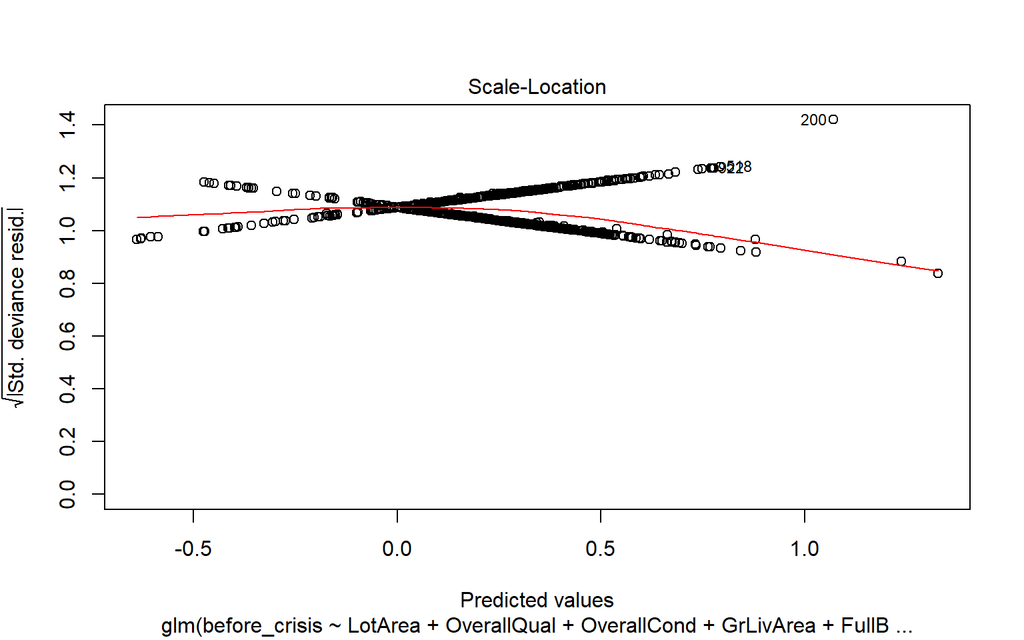

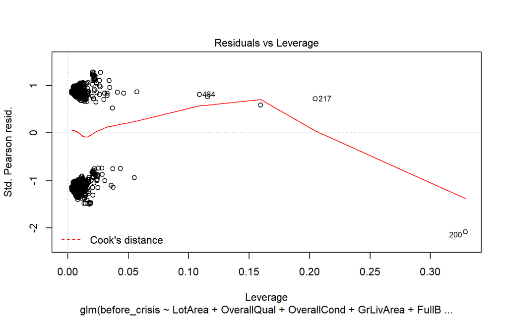

```r
plot(lr1)
```

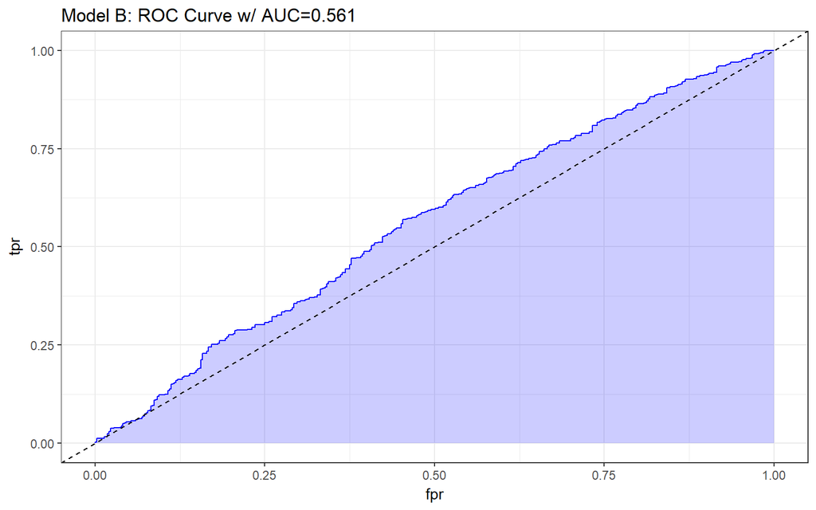

```r
prob <- predict(lr1, T8_data, type="response")
pred <- prediction(prob, T8_data$before_crisis)
perf <- performance(pred, measure = "tpr", x.measure = "fpr")
auc <- performance(pred, measure="auc")
auc <- round(auc@y.values[[1]],3)
roc.data <- data.frame(fpr=unlist(perf@x.values),
tpr=unlist(perf@y.values),
model="GLM")
ggplot(roc.data, aes(x=fpr, ymin=0, ymax=tpr)) +
geom_ribbon(alpha=0.2, fill = "blue") +
geom_line(aes(y=tpr), col = "blue") +
geom_abline(intercept = 0, slope = 1, lty = "dashed") +
labs(title = paste0("Model B: ROC Curve w/ AUC=", auc)) +
theme_bw()
```

# 9 Task 9: Affirmation

- I am certain that it is completely appropriate for these data to be shared with anyone, without any conditions. There are no concerns about privacy or security.

Bilal Zonjy

2018-03-08 12:45:37